# IODS course project

Anton Saressalo

# About the project

This is a course *Introduction to Open Data Science* at the University of Helsinki, in autumn 2017. The link to my progress can be found at https://github.com/saressal/IODS-project

# Chapter 2: Regression and model validation

## Data wrangling

The script to complete the data wrangling exercise in file chapter2_wrangling.R

## Exercise 1: Reading and exploring the data

Reading the csv file created in the data wrangling exercise and reading its dimensions:

```r
my_data = read.csv("data/chapter2data.csv",header=T,check.names=F)
str(my_data)
```

```
## 'data.frame':    166 obs. of  7 variables:
##  $ gender  : Factor w/ 2 levels "F","M": 1 2 1 2 2 1 2 1 2 1 ...
##  $ Age     : int  53 55 49 53 49 38 50 37 37 42 ...
##  $ Attitude: int  37 31 25 35 37 38 35 29 38 21 ...
##  $ Points  : int  25 12 24 10 22 21 21 31 24 26 ...
##  $ deep    : num  3.58 2.92 3.5 3.5 3.67 ...
##  $ surf    : num  2.58 3.17 2.25 2.25 2.83 ...
##  $ stra    : num  3.38 2.75 3.62 3.12 3.62 ...
```

The output tells that the data has 7 variables (or culumns) with 166 observations in each. The dataset measures the relation of course points and various questionnaire answers given by a subject group. Apart from the resulting points on the course, the measured variables were gender, age, attitude, deep learning points, surface learning points and strategic learning points.

## Exercise 2: Variable relations

Analyzing the data set with function ggpairs to draw all the possible scatter plots out of the dataset. We need the libraries ggplot2 and GGally to use the function. The arguments inside the mapping function aes create separate distributions for each gender for easier visibility. The alpha value makes all graphics partially transparent in order to be able to view all the data. The last argument defines the histograms and their bin numbers.

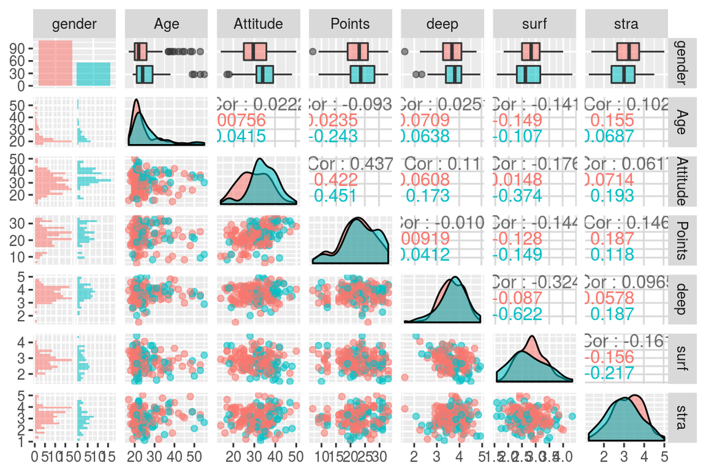

```r
library(ggplot2)
library(GGally)
ggpairs(my_data, mapping = aes(col=gender,alpha=0.3), lower = list(combo = wrap("facethist", bins = 20)))
```

From the graphs we can observe the following:

- About 2/3 of the observations are from females.
- Ages are mostly focused between 20 and 25 years, tough the oldest ones are over 50.
- Attitude, points, deep learning, surface learning and strategic learning are all more or less Gaussian distributions. Some better than the other.
- Differences between males and females can be noted mostly in attitudes and surface learning points, however, this does’t seem to affect the course points.
- Attitude and points have the highest positive correlation. This sounds quite self-explanatory, but it’s nice to also be proven with the numbers.
- Age seems to have small correlation to most other variables, which is also nice to see.

## Exercise 3: Regression fit

As the dependent variable (result) is points, we need to select the three explanatory variables that have the highest (absolute value) correlation with points. These are:

1. Attitude (0.437)
2. Strategic learning (0.146)
3. Surface learning (-0.144)

We need to note that the negative value means negative correlation, but that is also a result.

Fitting a linear regression model with function lm. We use Points as the dependent variable (**y**) and Attitude (**x_1**), stra (**x_2**) and surf (**x_3**) as explanatory variables. The function minimizes the matrix equation **y** = a_1 * **x_1** + a_2 * **x_2** + a_3 * **x_3** + b. The square of the difference between the model and measurements are calculated in each data point and their sum is minimized in order to get the optimal values.

We also print the results of the fit using function summary

```r
my_model = lm(Points ~ Attitude + stra + surf,data=my_data)
summary(my_model)
```

```
##
## Call:
## lm(formula = Points ~ Attitude + stra + surf, data = my_data)
##
## Residuals:
##      Min       1Q   Median       3Q      Max
## -17.1550  -3.4346   0.5156   3.6401  10.8952
##
## Coefficients:
##             Estimate Std. Error t value Pr(>|t|)
## (Intercept) 11.01711    3.68375   2.991  0.00322 **
## Attitude     0.33952    0.05741   5.913 1.93e-08 ***
## stra         0.85313    0.54159   1.575  0.11716
## surf        -0.58607    0.80138  -0.731  0.46563
## ---
## Signif. codes:  0 '***' 0.001 '**' 0.01 '*' 0.05 '.' 0.1 ' ' 1
##
## Residual standard error: 5.296 on 162 degrees of freedom
## Multiple R-squared:  0.2074, Adjusted R-squared:  0.1927
## F-statistic: 14.13 on 3 and 162 DF,  p-value: 3.156e-08
```

From here we see that the best fit for the data provides coefficients *intercept = b = 11.01 +/- 3.7, a_1 = 0.34 +/- 0.06, a_2 = 0.85 +/- 0.54 abd -a_3 = 0.59 +/- 0.80.

Now we notice that the error relative estimates of the last two parameters are really high, and also their P-values are greater than 0.1, implying that they are not significant for the model. => It seems that only Attitude is explaining the hehaviour of Points, so let’s remove these two other explanatory variables from the model.

```r
my_model2 = lm(Points ~ Attitude,data=my_data)
summary(my_model2)
```

```
##
## Call:
## lm(formula = Points ~ Attitude, data = my_data)
##
## Residuals:
##      Min       1Q   Median       3Q      Max
## -16.9763  -3.2119   0.4339   4.1534  10.6645
##
## Coefficients:
##             Estimate Std. Error t value Pr(>|t|)
## (Intercept) 11.63715    1.83035   6.358 1.95e-09 ***
## Attitude     0.35255    0.05674   6.214 4.12e-09 ***
## ---
## Signif. codes:  0 '***' 0.001 '**' 0.01 '*' 0.05 '.' 0.1 ' ' 1
##
## Residual standard error: 5.32 on 164 degrees of freedom
## Multiple R-squared:  0.1906, Adjusted R-squared:  0.1856
## F-statistic: 38.61 on 1 and 164 DF,  p-value: 4.119e-09
```

## Exercise 4: Analysis of the model

Now the fit results in **y** = (0.353 +/- 0.057)**x** + (11.64 +/- 1.83) abd we can see that the error estimates and P-values are even better for both the intercept and the slope. The P-values of 4.12e-9 and 1.95e-9 tell that this fit explains the data set with a really high probability.

Also the parameter Multiple R-squared went slightly down. It measures the squared distance between the fitted **y** and the measured **y**,

i.e. M-R^2 = (**y**-**y’**)<sup>2</sup>

Since now we have only one explanatory variable, R-squared and multiple R-squared are the same. In principal, the R-squared value always increases when more explanatory values are introduced in the model as there will be more degrees of freedom. The parameter Adjusted R-squared tries to compensate this and “normalize” the value to be comparable between different amount of explanatory variables. Luckily, also this value seems to be smaller in the latter model.

## Exercise 5: Model diagnostics

Plotting the diagnostics of the later model:

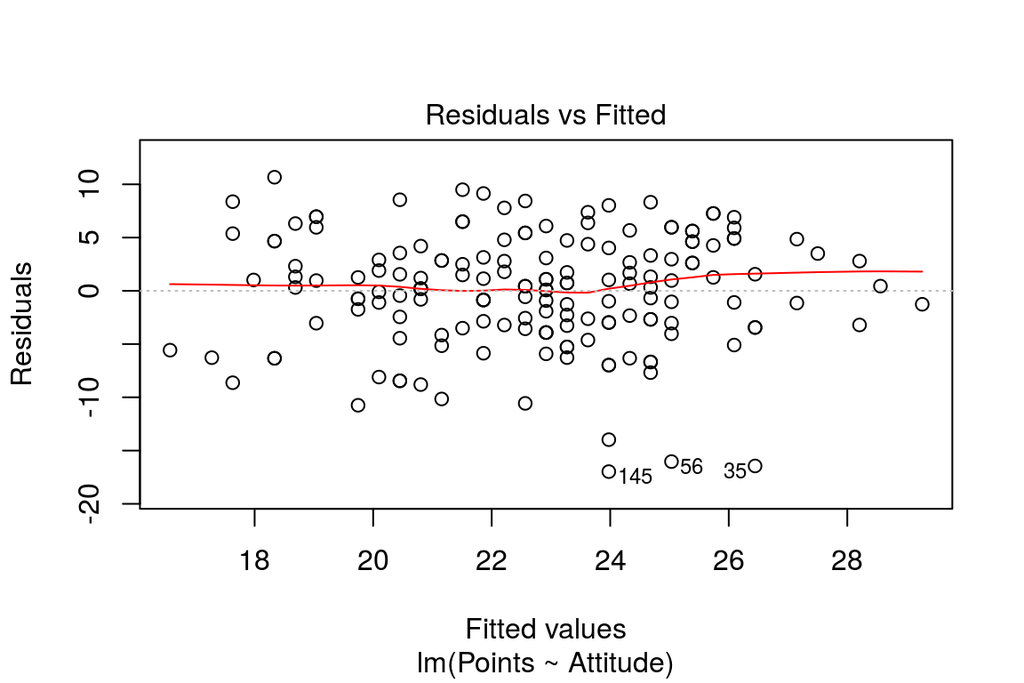

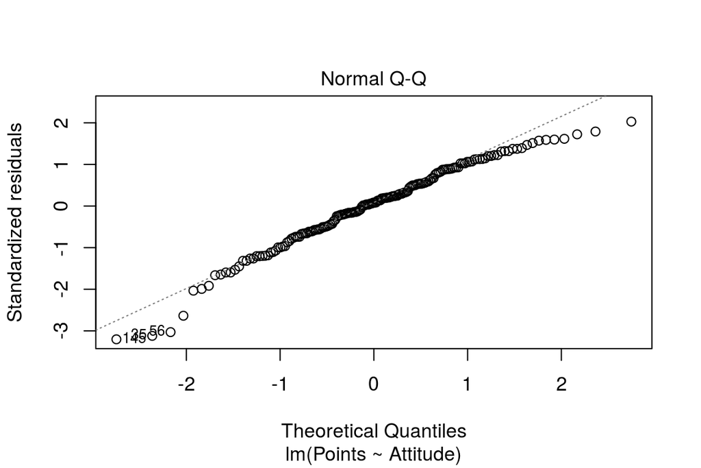

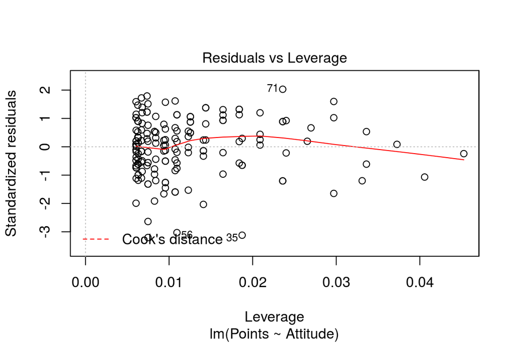

```r
plot(my_model2,which=c(1,2,5))
```

Fitting the model, we made several assumptions:

- There actually is a linear regression
- The errors are normally distributed (with constant variance), not covariant and not correlated to the explanatory variables
- Each data point has the same weight

The graph residuals vs Fitted tests the constant variance assumption. In the plot we see a more or less constant (or uniformly scattered) trend (red line) throughout the normal data set.

The last plot, Residuals vs Leverage can reveal if some observation has a higher impact on the result than the rest. From the resulting graph we see that most of the observations are located at the lower end of the x-axis, having a very similiar impact. A few points stand out, but still the deviation is less than 5 %.

In The Q-Q plot, we see the normality of the errors. From the graph we see that a vast majority of the data points fits to the filne reasonably well, but still there is some deviation in either end.

To conclude, it seems that the assumptions fit pretty well and since also both the relative errors are P-values are small, we can deduce that the fit describes the dataset reasonably well. All in all, this means that attitude has a good correlation with succeeding on the course - at least in this case.

# Chapter 4: Clustering and classification

## Exercise 2: Rading Boston data

Reading the Boston dataset from library MASS with data() and examining its content.

```r
library(MASS)
data("Boston")
str(Boston)
```

```
## 'data.frame':    506 obs. of  14 variables:
##  $ crim   : num  0.00632 0.02731 0.02729 0.03237 0.06905 ...
##  $ zn     : num  18 0 0 0 0 0 12.5 12.5 12.5 12.5 ...
##  $ indus  : num  2.31 7.07 7.07 2.18 2.18 2.18 7.87 7.87 7.87 7.87 ...
##  $ chas   : int  0 0 0 0 0 0 0 0 0 0 ...
##  $ nox    : num  0.538 0.469 0.469 0.458 0.458 0.458 0.524 0.524 0.524 0.524 ...
##  $ rm     : num  6.58 6.42 7.18 7 7.15 ...
##  $ age    : num  65.2 78.9 61.1 45.8 54.2 58.7 66.6 96.1 100 85.9 ...
##  $ dis    : num  4.09 4.97 4.97 6.06 6.06 ...
##  $ rad    : int  1 2 2 3 3 3 5 5 5 5 ...
##  $ tax    : num  296 242 242 222 222 222 311 311 311 311 ...
##  $ ptratio: num  15.3 17.8 17.8 18.7 18.7 18.7 15.2 15.2 15.2 15.2 ...
##  $ black  : num  397 397 393 395 397 ...
##  $ lstat  : num  4.98 9.14 4.03 2.94 5.33 ...
##  $ medv   : num  24 21.6 34.7 33.4 36.2 28.7 22.9 27.1 16.5 18.9 ...
```

In the dataset, we have 14 variables and 506 observations in each. All the observations are numerical and tell about various factors from different neighbourhoods of the city of Boston.

## Exercise 3: Graphical overview

Analyzing the data set with function ggpairs to draw all the possible scatter plots out of the dataset. We need the libraries ggplot2 and GGally to use the function.

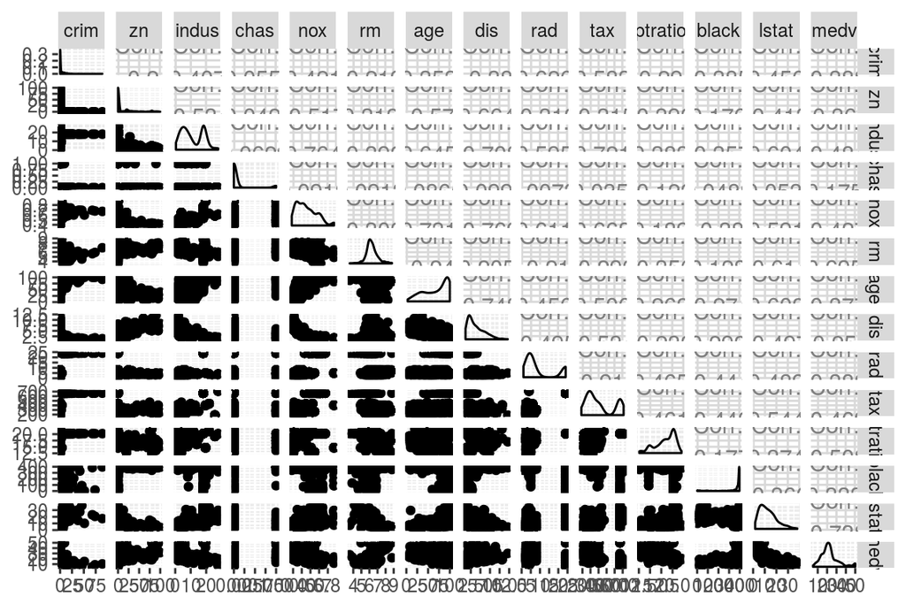

```r
library(ggplot2)
library(GGally)
ggpairs(Boston)
```

```r
summary(Boston)
```

```
##       crim                zn             indus            chas
##  Min.   : 0.00632   Min.   :  0.00   Min.   : 0.46   Min.   :0.00000
##  1st Qu.: 0.08204   1st Qu.:  0.00   1st Qu.: 5.19   1st Qu.:0.00000
##  Median : 0.25651   Median :  0.00   Median : 9.69   Median :0.00000
##  Mean   : 3.61352   Mean   : 11.36   Mean   :11.14   Mean   :0.06917
##  3rd Qu.: 3.67708   3rd Qu.: 12.50   3rd Qu.:18.10   3rd Qu.:0.00000
##  Max.   :88.97620   Max.   :100.00   Max.   :27.74   Max.   :1.00000
##       nox               rm             age              dis
##  Min.   :0.3850   Min.   :3.561   Min.   :  2.90   Min.   : 1.130
##  1st Qu.:0.4490   1st Qu.:5.886   1st Qu.: 45.02   1st Qu.: 2.100
##  Median :0.5380   Median :6.208   Median : 77.50   Median : 3.207
##  Mean   :0.5547   Mean   :6.285   Mean   : 68.57   Mean   : 3.795
##  3rd Qu.:0.6240   3rd Qu.:6.623   3rd Qu.: 94.08   3rd Qu.: 5.188
##  Max.   :0.8710   Max.   :8.780   Max.   :100.00   Max.   :12.127
##       rad              tax           ptratio          black
##  Min.   : 1.000   Min.   :187.0   Min.   :12.60   Min.   :  0.32
##  1st Qu.: 4.000   1st Qu.:279.0   1st Qu.:17.40   1st Qu.:375.38
##  Median : 5.000   Median :330.0   Median :19.05   Median :391.44
##  Mean   : 9.549   Mean   :408.2   Mean   :18.46   Mean   :356.67
##  3rd Qu.:24.000   3rd Qu.:666.0   3rd Qu.:20.20   3rd Qu.:396.23
##  Max.   :24.000   Max.   :711.0   Max.   :22.00   Max.   :396.90
##      lstat            medv
##  Min.   : 1.73   Min.   : 5.00
##  1st Qu.: 6.95   1st Qu.:17.02
##  Median :11.36   Median :21.20
##  Mean   :12.65   Mean   :22.53
##  3rd Qu.:16.95   3rd Qu.:25.00
##  Max.   :37.97   Max.   :50.00
```

From the graphs we can observe the following:

- Surprisingly, only “rm” (average number of rooms) seems to be normally distribyted. Many have only small peaks on either end of the scale and some have weirder, even double distributions visible.
- Without further investigation, it is difficult to see aby naked eye.ny correlations just from thee figures. Many of the variables seem to be quite clearly not correlated.
- From the summary, we see that all the numerical values are non-negative, but vary a lot between variables. Also, for example the crime rate has the mean that is really close to the minimum, but far away from the maximum.

## Exercise 4: Standardisation

Scaling all the variables with scale() and printing its summary

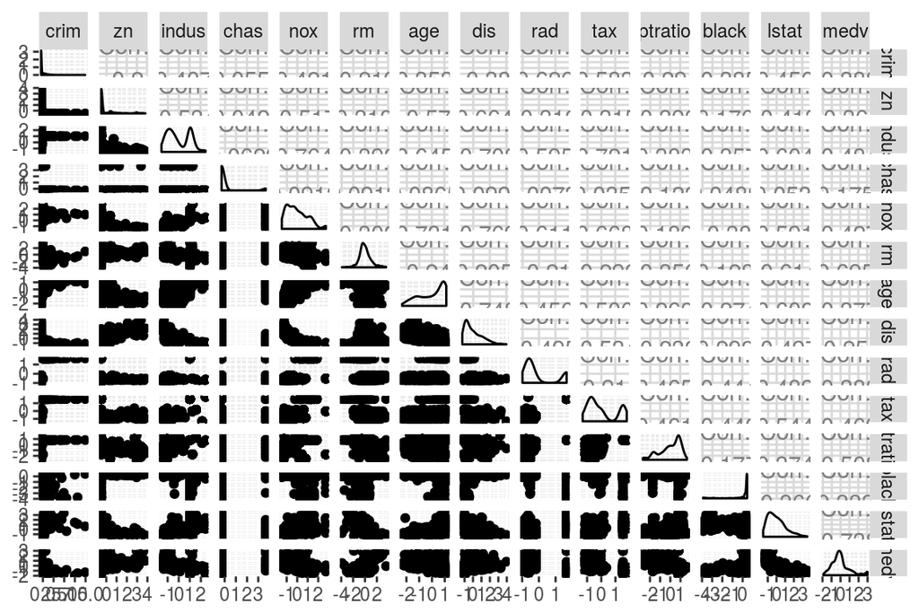

```r
Boston_scaled = as.data.frame(scale(Boston))
ggpairs(Boston_scaled)
```

```r
summary(Boston_scaled)
```

```
##       crim                 zn               indus
##  Min.   :-0.419367   Min.   :-0.48724   Min.   :-1.5563
##  1st Qu.:-0.410563   1st Qu.:-0.48724   1st Qu.:-0.8668
##  Median :-0.390280   Median :-0.48724   Median :-0.2109
##  Mean   : 0.000000   Mean   : 0.00000   Mean   : 0.0000
##  3rd Qu.: 0.007389   3rd Qu.: 0.04872   3rd Qu.: 1.0150
##  Max.   : 9.924110   Max.   : 3.80047   Max.   : 2.4202
##       chas              nox                rm               age
##  Min.   :-0.2723   Min.   :-1.4644   Min.   :-3.8764   Min.   :-2.3331
##  1st Qu.:-0.2723   1st Qu.:-0.9121   1st Qu.:-0.5681   1st Qu.:-0.8366
##  Median :-0.2723   Median :-0.1441   Median :-0.1084   Median : 0.3171
##  Mean   : 0.0000   Mean   : 0.0000   Mean   : 0.0000   Mean   : 0.0000
##  3rd Qu.:-0.2723   3rd Qu.: 0.5981   3rd Qu.: 0.4823   3rd Qu.: 0.9059
##  Max.   : 3.6648   Max.   : 2.7296   Max.   : 3.5515   Max.   : 1.1164
##       dis               rad               tax             ptratio
##  Min.   :-1.2658   Min.   :-0.9819   Min.   :-1.3127   Min.   :-2.7047
##  1st Qu.:-0.8049   1st Qu.:-0.6373   1st Qu.:-0.7668   1st Qu.:-0.4876
##  Median :-0.2790   Median :-0.5225   Median :-0.4642   Median : 0.2746
##  Mean   : 0.0000   Mean   : 0.0000   Mean   : 0.0000   Mean   : 0.0000
##  3rd Qu.: 0.6617   3rd Qu.: 1.6596   3rd Qu.: 1.5294   3rd Qu.: 0.8058
##  Max.   : 3.9566   Max.   : 1.6596   Max.   : 1.7964   Max.   : 1.6372
##      black             lstat              medv
##  Min.   :-3.9033   Min.   :-1.5296   Min.   :-1.9063
##  1st Qu.: 0.2049   1st Qu.:-0.7986   1st Qu.:-0.5989
##  Median : 0.3808   Median :-0.1811   Median :-0.1449
##  Mean   : 0.0000   Mean   : 0.0000   Mean   : 0.0000
##  3rd Qu.: 0.4332   3rd Qu.: 0.6024   3rd Qu.: 0.2683
##  Max.   : 0.4406   Max.   : 3.5453   Max.   : 2.9865
```

Now the data values are comparable with each other, but of course, the numerical values are not directly the observations any more. Now we can see even more clearly that the maximal crime rate is almost 10 units away from the mean value, whereas the next biggest value can be found in dis (distances to employment centres). Almost all of the values between 25 % and 75 % are within 1 unit away from the mean.

In the pairs plot, we do not see any change in the distributions nor correlations - as should be the case.

Next, creating a categorical variable from the crime rate and replacing the variable from the dataset

```r
library(dplyr)
crime_quantiles = quantile(Boston_scaled$crim)
crime <- cut(Boston_scaled$crim, breaks = crime_quantiles, include.lowest = TRUE)
Boston_scaled = select(Boston_scaled,-crim)
Boston_scaled = data.frame(Boston_scaled,crime)
```

Dividing the data by by drawing random rows with sample

```r
idx = sample(nrow(Boston_scaled), size=0.8*nrow(Boston_scaled))
Boston_train = Boston_scaled[idx,]
Boston_test = Boston_scaled[-idx,]
```

## Exercise 5: Linear discriminant analysis

Create the LDA fit and plot it

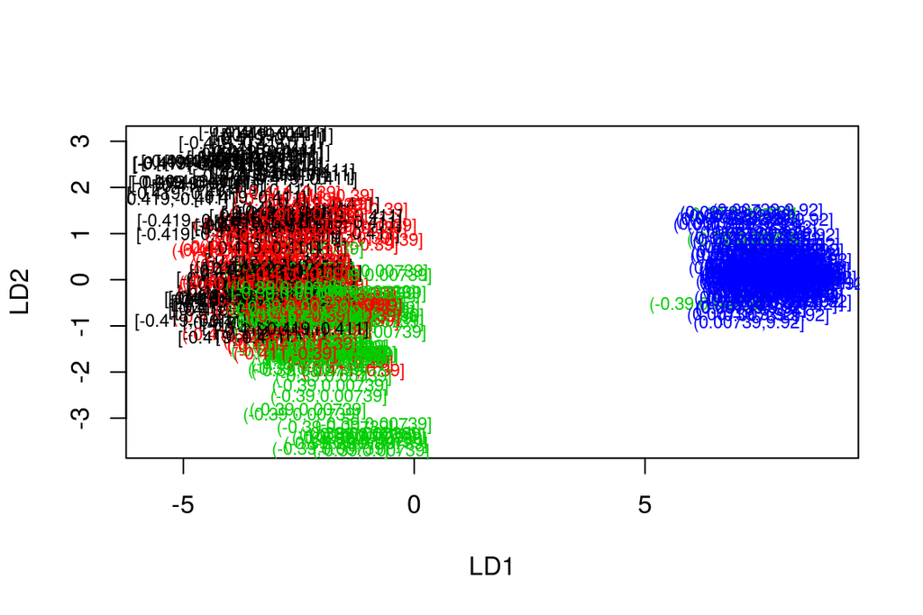

```r
lda.fit = lda(crime ~ ., data=Boston_train)
classes = as.numeric(Boston_train$crime)
plot(lda.fit,col=classes,pch=classes,dimen=2)
```

## Exercise 6: LDA results Saving crime categories and removing them from the test set

```r
Boston_test_crime = Boston_test$crime
Boston_test = select(Boston_test,-crime)
```

Predicting the results and printing the cross-validation table

```r
lda.pred = predict(lda.fit,newdata=Boston_test)
table(correct=Boston_test_crime,predicted=lda.pred$class)
```

```
##                  predicted
## correct           [-0.419,-0.411] (-0.411,-0.39] (-0.39,0.00739]
##   [-0.419,-0.411]              16              9               0
##   (-0.411,-0.39]                2             17               6
##   (-0.39,0.00739]               1              6              20
##   (0.00739,9.92]                0              0               1
##                  predicted
## correct           (0.00739,9.92]
##   [-0.419,-0.411]              0
##   (-0.411,-0.39]               0
##   (-0.39,0.00739]              3
##   (0.00739,9.92]              21
```

## Exercise 7: k-means tests

Reloading the data set and standardizing it

```r
data("Boston")
Boston_scaled = as.data.frame(scale(Boston))
```

Calculating the euclidean distances with dist()

```r
distances = dist(Boston_scaled)
```

Using the k-means algorithm, finding the optimal number of clusters

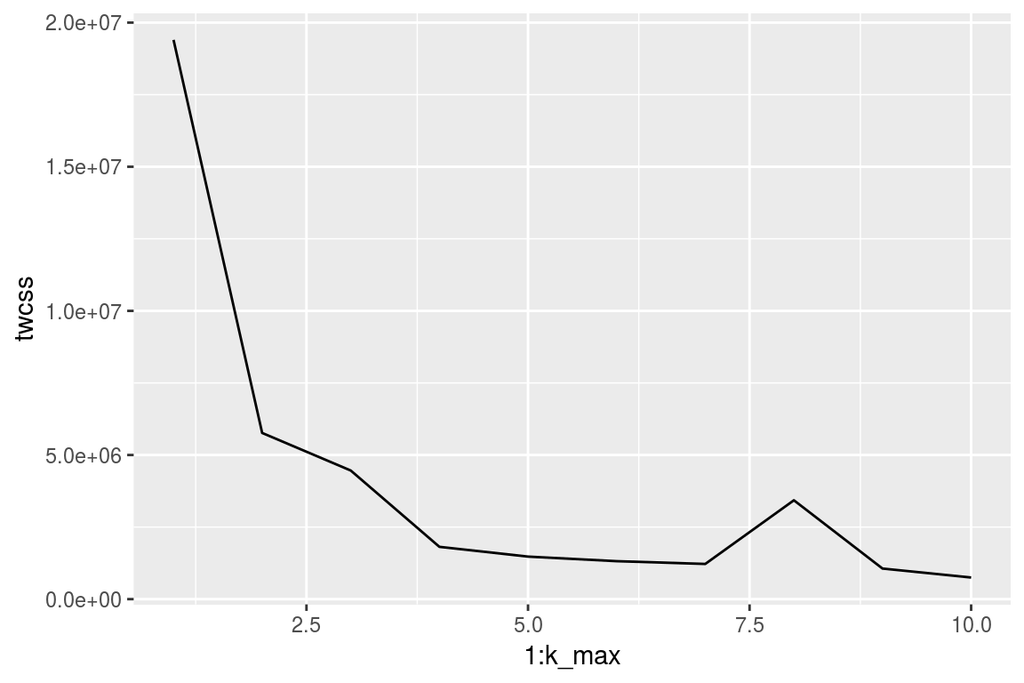

```r
k_max = 10
twcss <- sapply(1:k_max, function(k){kmeans(Boston, k)$tot.withinss})
qplot(x = 1:k_max, y = twcss, geom = 'line')
```

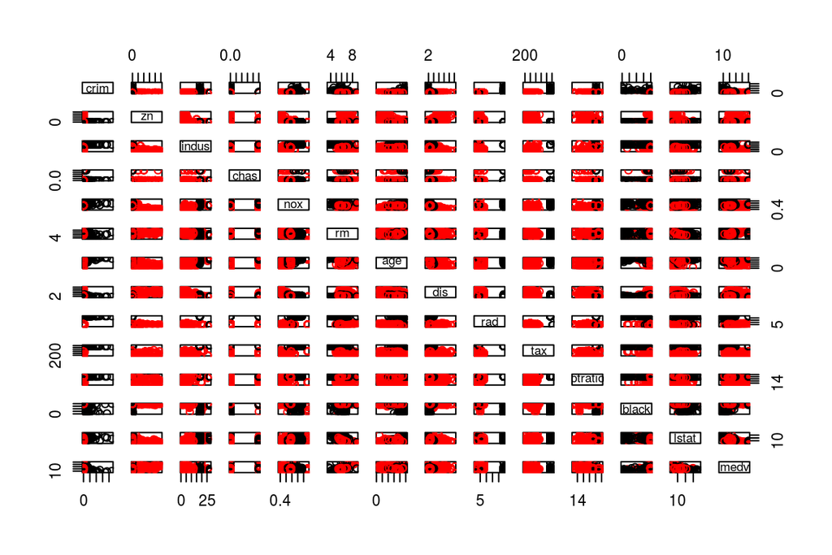

```r
km.fit = kmeans(Boston, centers=2)
pairs(Boston,col=km.fit$cluster)
```

From the (tiny) plots we can see that most of the data is actually quite nicely clustered into two regions, meaning that their classification would be predicted with good odds. However, some variables, such as nox (nigrogen oxide concentration) seem to be much worse compared tto the best ones, such as rad (accessibility to radial highways).

# Chapter 5: Dimensionality reduction techniques

## Exercise 1: Loading the human data

```r
library(dplyr)
human = read.csv("data/human_2.csv",header=TRUE)
rownames(human) = human$X
human = select(human,-X)
glimpse(human)
```

```
## Observations: 155
## Variables: 8
## $ education_ratio    <dbl> 1.0072389, 0.9968288, 0.9834369, 0.9886128,...
## $ labour_ratio       <dbl> 0.8908297, 0.8189415, 0.8251001, 0.8840361,...
## $ exp_life           <dbl> 81.6, 82.4, 83.0, 80.2, 81.6, 80.9, 80.9, 7...
## $ exp_education      <dbl> 17.5, 20.2, 15.8, 18.7, 17.9, 16.5, 18.6, 1...
## $ GNI                <int> 64992, 42261, 56431, 44025, 45435, 43919, 3...
## $ maternal_mortality <int> 4, 6, 6, 5, 6, 7, 9, 28, 11, 8, 6, 4, 8, 4,...
## $ birth_rate         <dbl> 7.8, 12.1, 1.9, 5.1, 6.2, 3.8, 8.2, 31.0, 1...
## $ parliament_F       <dbl> 39.6, 30.5, 28.5, 38.0, 36.9, 36.9, 19.9, 1...
```

The dataset human describes the variables related to the Human Development Index (HDI). It includes 155 observations in 9 variables, which are X (row names): Country name educations_ratio: The relative amount of females with at least a secondary education compared to males labour_ratio: The relative amount of females in labour work compared to males exp_life: Life expectancy at birth GNI: Gross National Income per capita maternal_mortality: Maternal mortality ratio birth_rate: Adolescent birth rate parliament_F: percentage of females in the parliament representatives

## Exercise 2: Graphical overview

Analyzing the data set with function ggpairs to draw all the possible scatter plots out of the dataset. We need the libraries ggplot2 and GGally to use the function.

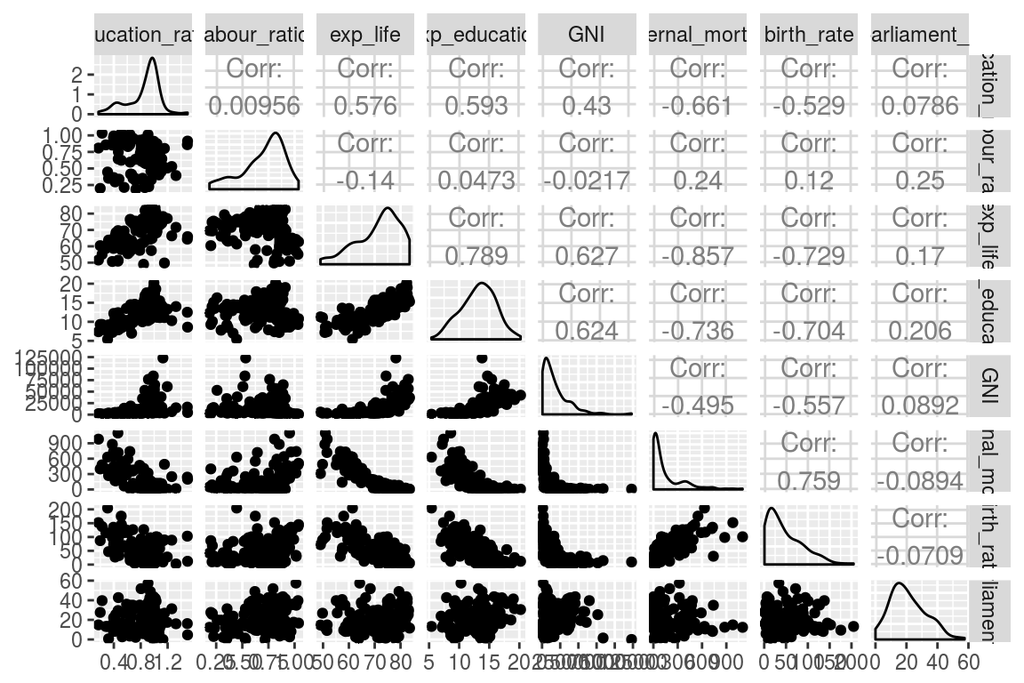

```r
library(ggplot2)
library(GGally)
ggpairs(human)
```

From the graphs we can observe the following:

- There seems to be relative big deviations in all of the variables. Education_ratio, labour_ratio, exp_life, birth_rate and parliament show a tilted/shifted gaussian. GNI and maternal mortality show a large concentration in one end while only a few countries are in the other.
- The largest correlations seem to be between maternal_mortality and exp_life (negative), exp_education and exp_life (positive) as well as birth_rate and maternal_mortality (positive).

```r
summary(human)
```

```
##  education_ratio   labour_ratio       exp_life     exp_education
##  Min.   :0.1717   Min.   :0.1857   Min.   :49.00   Min.   : 5.40
##  1st Qu.:0.7264   1st Qu.:0.5984   1st Qu.:66.30   1st Qu.:11.25
##  Median :0.9375   Median :0.7535   Median :74.20   Median :13.50
##  Mean   :0.8529   Mean   :0.7074   Mean   :71.65   Mean   :13.18
##  3rd Qu.:0.9968   3rd Qu.:0.8535   3rd Qu.:77.25   3rd Qu.:15.20
##  Max.   :1.4967   Max.   :1.0380   Max.   :83.50   Max.   :20.20
##       GNI         maternal_mortality   birth_rate      parliament_F
##  Min.   :   581   Min.   :   1.0     Min.   :  0.60   Min.   : 0.00
##  1st Qu.:  4198   1st Qu.:  11.5     1st Qu.: 12.65   1st Qu.:12.40
##  Median : 12040   Median :  49.0     Median : 33.60   Median :19.30
##  Mean   : 17628   Mean   : 149.1     Mean   : 47.16   Mean   :20.91
##  3rd Qu.: 24512   3rd Qu.: 190.0     3rd Qu.: 71.95   3rd Qu.:27.95
##  Max.   :123124   Max.   :1100.0     Max.   :204.80   Max.   :57.50
```

From the summaries, we can observe the same things. maternal_mortality and GNI have really large variations compared to others.

## Exercise 3: Principal comoponent analysis

Performing the PCA with prcomp() and plotting the principal components

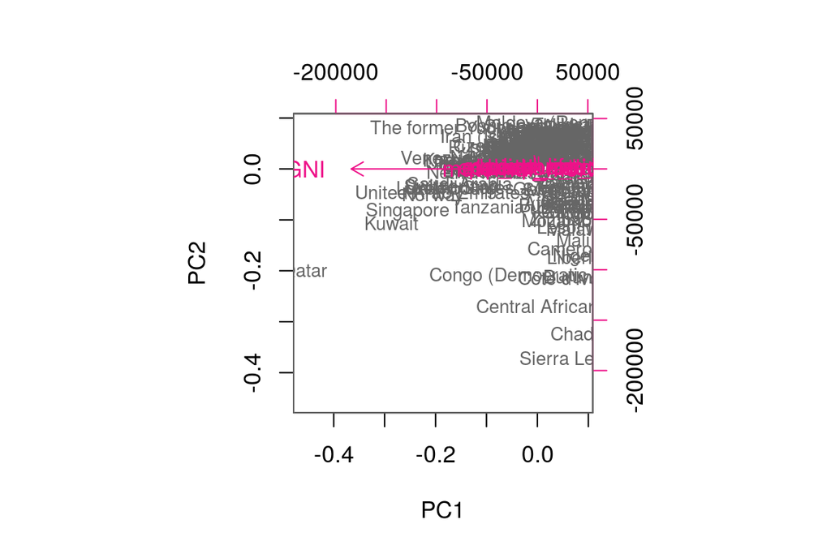

```r
pca_human = prcomp(human)
biplot(pca_human, choices = 1:2, cex=c(0.8,1),col=c("grey40","deeppink2"))
```

Caption: PCA analysis for non-standardized HDI data, where GNI is the principal explanation for basically all the explanations.

Not a very good analysis, since the high absolute values of GNI govern everything else. However, here we can see that the first principal component PC1 is parallel with GNI. Thus, in this analysis GNI is explaining all the observations.

## Exercise r: PCA with standardized data

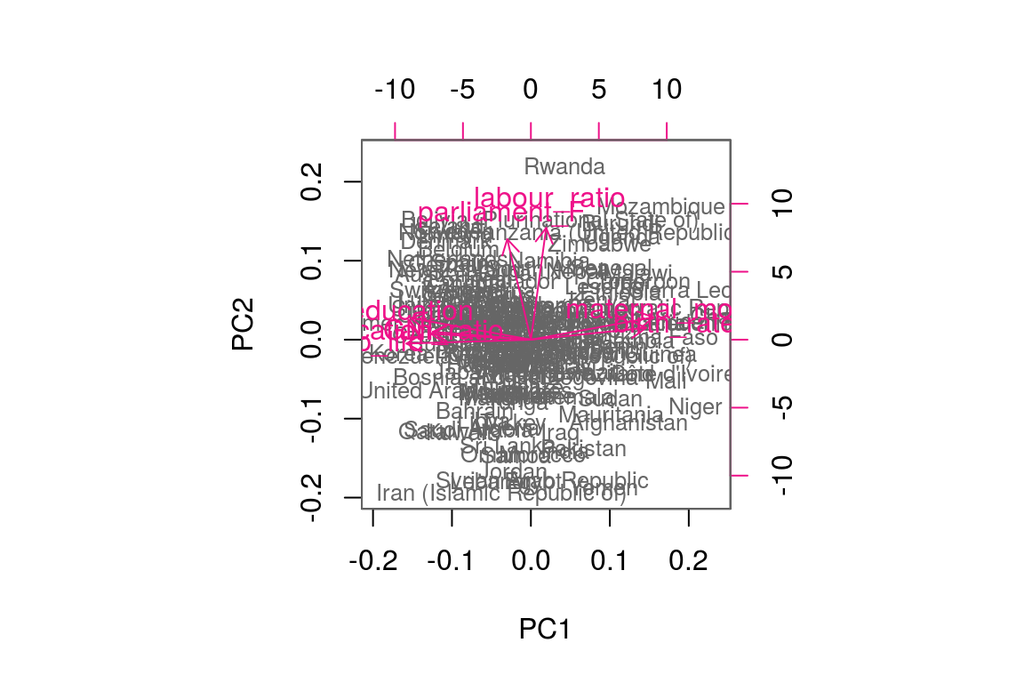

```r
human_std = scale(human)
pca_human_std = prcomp(human_std)
biplot(pca_human_std, choices = 1:2, cex=c(0.8,1),col=c("grey40","deeppink2"))
```

Caption: PCA analysis for the standardized HDI data. Now there are three groups of variables explaining the observations.

Now the analysis is much better, as the relative values of different observables are comparable with each other, i.e. all the variables have equal weights instead GNI governing it all.

## Exercise 5: Principal components

Here PC1 is the first principal component and it seems to be related to the richness of the country. Variables which have negative correlation with wellbeing, such as adolescent birth rate and maternal mortality are on the other edge, while so called “good” values such as expected education and life expectancy have almost exactly opposite correlation.

On the other axis (PC2) seems to be the variables realted to equality, such as share of females in parliament and labour. Strangely, this seems to be almost orthogonal to the other “good” variables. Also, one of the “equality” variables, education ratio is highly correlated with the other “good” variables.

## Exercise 6: Factominer & MCA

Loading the tea dataset from http://factominer.free.fr/course/doc/data_MCA_Tea.csv And using the examplesat script http://factominer.free.fr/course/doc/script_CA_Birth.R to read it

```r
tea <- read.table("data/data_MCA_Tea.csv", header=TRUE, sep=";")
summary(tea)
```

```
##          breakfast           tea.time          evening          lunch
##  breakfast    :144   Not.tea time:131   evening    :103   lunch    : 44
##  Not.breakfast:156   tea time    :169   Not.evening:197   Not.lunch:256
##
##
##
##
##
##         dinner           always          home           work
##  dinner    : 21   always    :103   home    :291   Not.work:213
##  Not.dinner:279   Not.always:197   Not.home:  9   work    : 87
##
##
##
##
##
##         tearoom           friends          resto          pub
##  Not.tearoom:242   friends    :196   Not.resto:221   Not.pub:237
##  tearoom    : 58   Not.friends:104   resto    : 79   pub    : 63
##
##
##
##
##
##         Tea         How           sugar                     how
##  black    : 74   alone:195   No.sugar:155   tea bag           :170
##  Earl Grey:193   lemon: 33   sugar   :145   tea bag+unpackaged: 94
##  green    : 33   milk : 63                  unpackaged        : 36
##                  other:  9
##
##
##
##                   where                 price          age        sex
##  chain store         :192   p_branded      : 95   Min.   :15.00   F:178
##  chain store+tea shop: 78   p_cheap        :  7   1st Qu.:23.00   M:122
##  tea shop            : 30   p_private label: 21   Median :32.00
##                             p_unknown      : 12   Mean   :37.05
##                             p_upscale      : 53   3rd Qu.:48.00
##                             p_variable     :112   Max.   :90.00
##
```

[output cut: 25 more lines]

```
##  feminine    :129   Not.sophisticated: 85   No.slimming:255
##  Not.feminine:171   sophisticated    :215   slimming   : 45
##
##
##
##
##
##         exciting          relaxing              effect.on.health
##  exciting   :116   No.relaxing:113   effect on health   : 66
##  No.exciting:184   relaxing   :187   No.effect on health:234
##
##
##
##
##
```

```r
str(tea)
```

```
## 'data.frame':    300 obs. of  36 variables:
##  $ breakfast       : Factor w/ 2 levels "breakfast","Not.breakfast": 1 1 2 2 1 2 1 2 1 1 ...
##  $ tea.time        : Factor w/ 2 levels "Not.tea time",..: 1 1 2 1 1 1 2 2 2 1 ...
##  $ evening         : Factor w/ 2 levels "evening","Not.evening": 2 2 1 2 1 2 2 1 2 1 ...
##  $ lunch           : Factor w/ 2 levels "lunch","Not.lunch": 2 2 2 2 2 2 2 2 2 2 ...
##  $ dinner          : Factor w/ 2 levels "dinner","Not.dinner": 2 2 1 1 2 1 2 2 2 2 ...
##  $ always          : Factor w/ 2 levels "always","Not.always": 2 2 2 2 1 2 2 2 2 2 ...
##  $ home            : Factor w/ 2 levels "home","Not.home": 1 1 1 1 1 1 1 1 1 1 ...
##  $ work            : Factor w/ 2 levels "Not.work","work": 1 1 2 1 1 1 1 1 1 1 ...
##  $ tearoom         : Factor w/ 2 levels "Not.tearoom",..: 1 1 1 1 1 1 1 1 1 2 ...
##  $ friends         : Factor w/ 2 levels "friends","Not.friends": 2 2 1 2 2 2 1 2 2 2 ...
##  $ resto           : Factor w/ 2 levels "Not.resto","resto": 1 1 2 1 1 1 1 1 1 1 ...
##  $ pub             : Factor w/ 2 levels "Not.pub","pub": 1 1 1 1 1 1 1 1 1 1 ...
##  $ Tea             : Factor w/ 3 levels "black","Earl Grey",..: 1 1 2 2 2 2 2 1 2 1 ...
##  $ How             : Factor w/ 4 levels "alone","lemon",..: 1 3 1 1 1 1 1 3 3 1 ...
```

[output cut: 22 more lines]

The dataset contains 36 variables and 300 observations related to drinking tea. Almost all the results are string variables.

Plotting the dataset

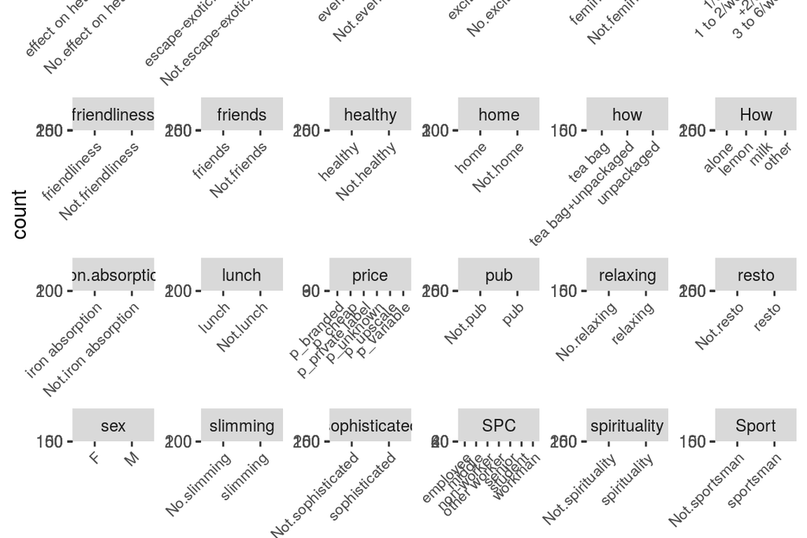

```r
library(tidyr)
gather(tea) %>% ggplot(aes(value)) + facet_wrap("key", scales = "free") + geom_bar() + theme(axis.text.x = element_text(angle = 45, hjust = 1, size=8))
```

The visualization doesn’t really show much as there are so many variables.

=> Restricting the variables to “Tea”, “How”, “how”, “sugar”, “where” and “lunch”.

```r
keep_columns = c("Tea", "How", "how", "sugar", "where", "lunch")
tea_kept = select(tea,one_of(keep_columns))
```

Plotting it again:

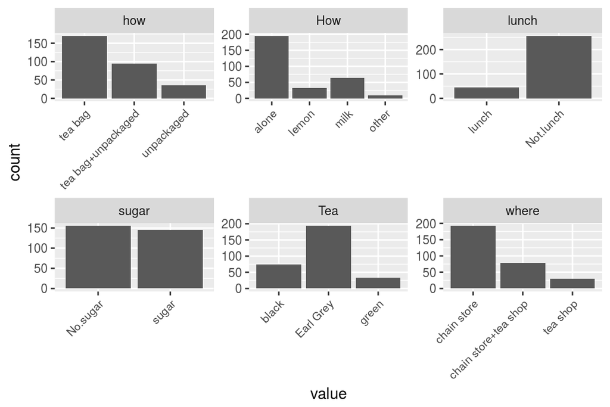

```r
gather(tea_kept) %>% ggplot(aes(value)) + facet_wrap("key", scales = "free") + geom_bar() + theme(axis.text.x = element_text(angle = 45, hjust = 1, size=8))
```

Now the results are much clearer.

Next, the Multiple correspondence analysis: “tea_mca = MCA(tea_kept,graph=FALSE)”

Some strange errors in installin FactoMineR => Cannot conclude the analysis.